# Étude pharmaco-épidémiologique sur l’abandon du traitement antihypertenseur Analyse de survie sur données simulées de type SNDS

Jean-Eude GBADA

10 June 2026

> **Note méthodologique** : Les données utilisées dans cette étude sont entièrement simulées à des fins pédagogiques et méthodologiques. Elles reproduisent la structure des tables du Système National des Données de Santé (SNDS) sans contenir aucune donnée réelle de patient. L’objectif est de démontrer la maîtrise des méthodes pharmaco- épidémiologiques appliquées aux bases médico-administratives.

# 1 Contexte et objectifs

## 1.1 Contexte scientifique

L’hypertension artérielle (HTA) est la pathologie chronique la plus fréquente en France, touchant environ 15 millions de patients traités. La non-observance thérapeutique représente un enjeu majeur de santé publique : on estime qu’entre 30 et 50% des patients abandonnent leur traitement dans l’année suivant l’initiation, exposant ainsi à un risque cardiovasculaire accru.

Le Système National des Données de Santé (SNDS) offre un cadre unique pour l’étude de l’observance en vie réelle, couvrant plus de 66 millions de bénéficiaires avec un historique de remboursements depuis 2006. Les études pharmaco-épidémiologiques conduites par le GIS EPI-PHARE (ANSM/CNAM) s’appuient sur cette base pour éclairer les décisions de santé publique.

## 1.2 Objectif principal

Estimer le délai d’abandon du traitement antihypertenseur dans les 12 mois suivant l’initiation et comparer ce risque entre les deux classes thérapeutiques les plus prescrites : les inhibiteurs de l’enzyme de conversion (IEC) et les antagonistes des récepteurs de l’angiotensine II (ARA2).

## 1.3 Objectifs secondaires

- Identifier les facteurs associés à l’abandon thérapeutique
- Évaluer la robustesse des résultats par des analyses de sensibilité
- Quantifier le risque de biais résiduel par le calcul de l’E-value

# 2 Méthodes

## 2.1 Source de données

Les données ont été simulées pour reproduire la structure des tables principales du SNDS :

Tables simulées et équivalents SNDS

| Table simulée | Équivalent SNDS | Contenu |
| --- | --- | --- |
| ir_ben_r | IR_BEN_R | Caractéristiques socio-démographiques des bénéficiaires |
| er_pha_f | ER_PHA_F (DCIR) | Délivrances de médicaments remboursés en pharmacie de ville |
| mco_b | MCO_B (PMSI) | Résumés de sortie d’hospitalisation (diagnostics CIM-10) |
| ald | Table ALD | Affections longue durée (comorbidités chroniques) |

## 2.2 Population d’étude

### 2.2.1 Critères d’inclusion

- Patient de 40 à 80 ans à la date d’initiation du traitement
- Primo-initiation d’un antihypertenseur entre le 01/01/2020 et le 31/12/2022
- Suivi minimal de 28 jours disponible après l’initiation

### 2.2.2 Critères d’exclusion

- Insuffisance rénale chronique sévère (score de Charlson ≥ 4 avec IRC)
- Données manquantes sur les variables essentielles à l’analyse
- Suivi inférieur à 28 jours

## 2.3 Définition de l’événement

L’**abandon thérapeutique** est défini comme l’absence de renouvellement dans les 365 jours suivant l’initiation, avec moins de 3 délivrances totales. Les patients sans événement sont censurés à la fin du suivi (365 jours) ou à la date de fin de la période d’étude.

## 2.4 Méthodes statistiques

### 2.4.1 Score de propension

Afin de contrôler le **biais d’indication** inhérent aux données observationnelles — le médecin prescrivant une classe plutôt qu’une autre en fonction des caractéristiques du patient —, un score de propension a été calculé par régression logistique :

$$P(\text{IEC} \mid \text{âge, sexe,
comorbidités, hospitalisations, CMU})$$

Un appariement 1:1 par *nearest neighbor* avec un caliper de 0,2 écart-type du logit du score de propension a été réalisé sans remise (Austin, 2011). La balance des covariables a été évaluée par la différence standardisée moyenne (SMD), le seuil d’équilibre acceptable étant fixé à SMD < 0,10.

### 2.4.2 Analyse de survie

- **Courbes de Kaplan-Meier** avec test log-rank pour la comparaison des classes thérapeutiques
- **Modèle de Cox multivarié** avec méthode d’Efron pour la gestion des ex aequo
- **Test de Schoenfeld** pour la vérification de l’hypothèse des risques proportionnels

### 2.4.3 Analyses de sensibilité

Cinq analyses de sensibilité ont été conduites :

1. Définitions alternatives de l’abandon (seuils de 300 et 330 jours)
2. Restriction aux patients sans comorbidité majeure (Charlson = 0)
3. Analyses par sous-groupes (sexe, âge, diabète)
4. Modèle de risques compétitifs cause-specific (Fine & Gray)
5. Calcul de l’E-value (VanderWeele & Ding, 2017)

# 3 Résultats

## 3.1 Construction de la cohorte

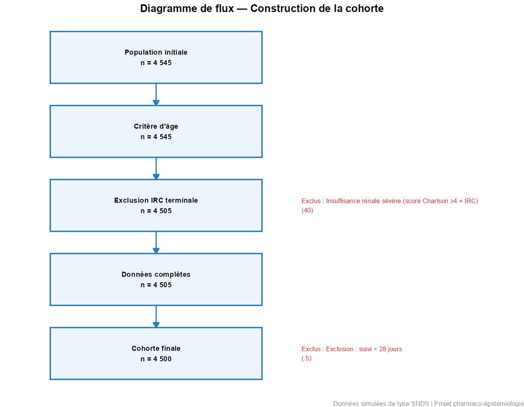

Diagramme de flux — Construction de la cohorte analytique

Flux de patients — Critères d’inclusion et d’exclusion

| Étape | N patients | N exclus | Raison |
| --- | --- | --- | --- |
| Population initiale | 4 545 | 0 | Ensemble des patients avec ≥1 délivrance d’antihypertenseur |
| Critère d’âge | 4 545 | 0 | Exclusion : âge < 40 ans ou > 80 ans |
| Exclusion IRC terminale | 4 505 | 40 | Insuffisance rénale sévère (score Charlson ≥4 + IRC) |
| Données complètes | 4 505 | 0 | Exclusion : données manquantes sur variables essentielles |
| Cohorte finale | 4 500 | 5 | Exclusion : suivi < 28 jours |

La cohorte finale comprend **4 500 patients**, dont **795 événements d’abandon** (taux : 17.7%).

## 3.2 Caractéristiques de la cohorte

Tableau 1 — Caractéristiques de la cohorte par classe thérapeutique

|  | ARA2 | ASSOCIATION | BB | DIURETIQUE | ICC | IEC |
| --- | --- | --- | --- | --- | --- | --- |
| n | 1105 | 199 | 826 | 379 | 648 | 1343 |
| age_inclusion (mean (SD)) | 59.95 (11.91) | 60.39 (11.82) | 61.03 (11.83) | 60.70 (11.84) | 60.21 (12.04) | 60.63 (11.63) |
| ben_sex_cod = 2 (%) | 545 (49.3) | 99 (49.7) | 442 (53.5) | 199 (52.5) | 335 (51.7) | 712 (53.0) |
| ald_diabete = 1 (%) | 237 (21.4) | 35 (17.6) | 179 (21.7) | 85 (22.4) | 141 (21.8) | 313 (23.3) |
| ald_insuf_card = 1 (%) | 92 (8.3) | 18 (9.0) | 66 (8.0) | 34 (9.0) | 58 (9.0) | 121 (9.0) |
| score_charlson (mean (SD)) | 0.60 (0.91) | 0.62 (0.87) | 0.63 (0.90) | 0.67 (0.94) | 0.58 (0.87) | 0.65 (0.91) |
| nb_hospitalisations (mean (SD)) | 0.21 (0.41) | 0.20 (0.40) | 0.16 (0.37) | 0.23 (0.42) | 0.21 (0.41) | 0.20 (0.40) |
| ben_cmu_top = 1 (%) | 67 (6.1) | 14 (7.0) | 54 (6.5) | 25 (6.6) | 38 (5.9) | 96 (7.1) |

## 3.3 Analyse de survie — Toutes les classes

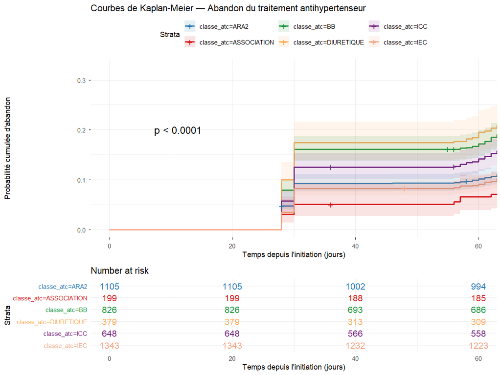

Courbes de Kaplan-Meier — Probabilité cumulée d’abandon par classe thérapeutique

Taux d’abandon à 12 mois par classe thérapeutique

| Classe ATC | N | N abandons | Taux (%) | Délai médian (j) |
| --- | --- | --- | --- | --- |
| DIURETIQUE | 379 | 105 | 27.7 | 196 |
| BB | 826 | 193 | 23.4 | 222 |
| ICC | 648 | 125 | 19.3 | 290 |
| ARA2 | 1105 | 169 | 15.3 | 357 |
| IEC | 1343 | 185 | 13.8 | 358 |
| ASSOCIATION | 199 | 18 | 9.0 | 365 |

## 3.4 Score de propension — IEC vs ARA2

### 3.4.1 Distribution du score de propension

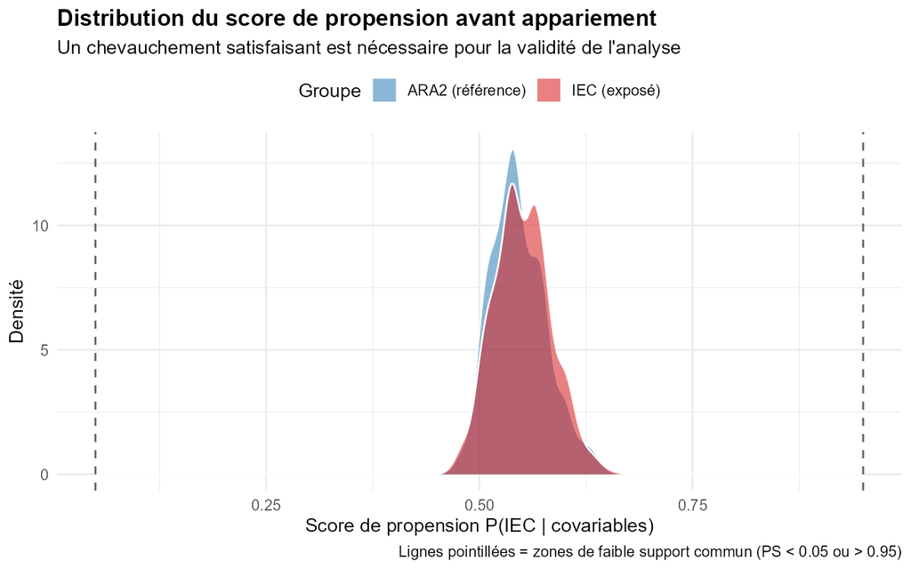

Distribution du score de propension avant appariement — Évaluation du support commun

### 3.4.2 Balance des covariables

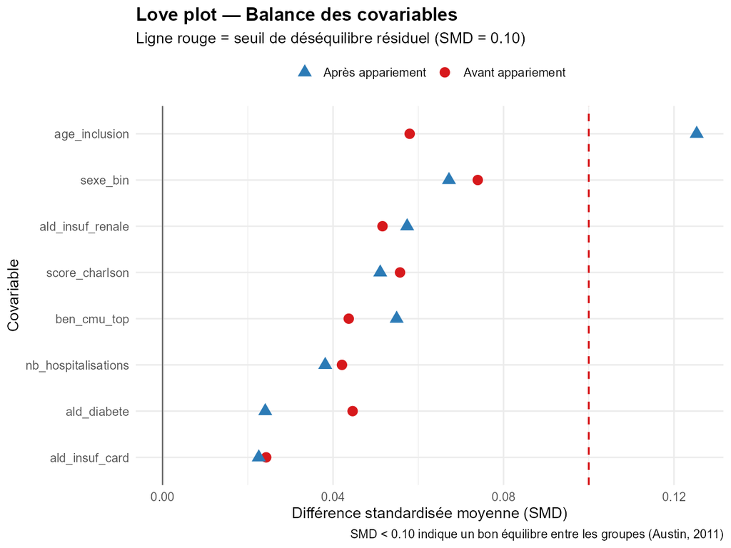

Love plot — Balance des covariables avant et après appariement par score de propension

Différences standardisées moyennes (SMD) avant et après appariement

| Variable | Avant appariement | Après appariement | Équilibre |
| --- | --- | --- | --- |
| age_inclusion | 0.058 | 0.125 | ⚠️ Résiduel |
| sexe_bin | 0.074 | 0.067 | ✅ Acceptable \| |
| ald_diabete | 0.045 | 0.024 | ✅ Acceptable \| |
| ald_insuf_card | 0.024 | 0.023 | ✅ Acceptable \| |
| ald_insuf_renale | 0.052 | 0.057 | ✅ Acceptable \| |
| score_charlson | 0.056 | 0.051 | ✅ Acceptable \| |
| nb_hospitalisations | 0.042 | 0.038 | ✅ Acceptable \| |
| ben_cmu_top | 0.044 | 0.055 | ✅ Acceptable \| |

### 3.4.3 Kaplan-Meier IEC vs ARA2 (données appariées)

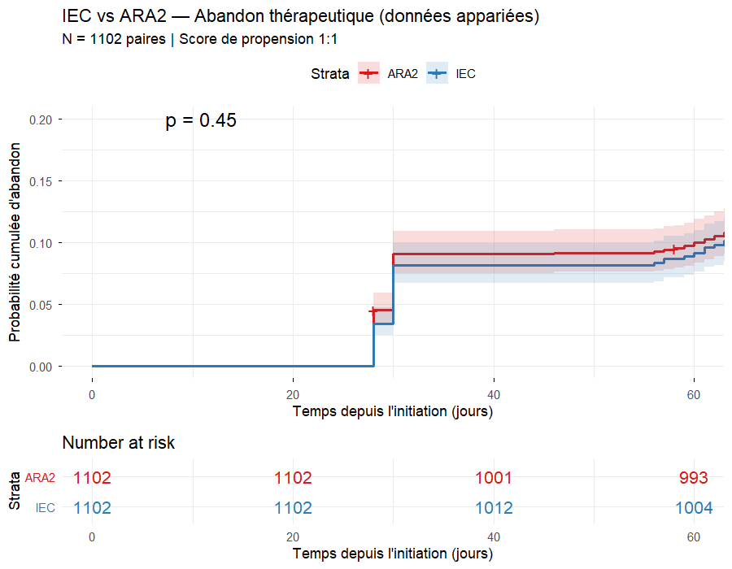

Courbes de Kaplan-Meier — IEC vs ARA2 sur données appariées par score de propension

Le test log-rank ne met pas en évidence de différence significative entre IEC et ARA2 après appariement (**p = 0.4484**).

## 3.5 Modèle de Cox multivarié

Modèle de Cox multivarié — Hazard ratios ajustés (IC 95%)

| Covariable | HR (IC 95%) | p |
| --- | --- | --- |
| classe_atcASSOCIATION | 0.58 (0.36–0.94) | 0.027 |
| classe_atcBB | 1.62 (1.31–1.99) | <0,001 |
| classe_atcDIURETIQUE | 1.96 (1.53–2.50) | <0,001 |
| classe_atcICC | 1.30 (1.03–1.63) | 0.028 |
| classe_atcIEC | 0.89 (0.72–1.10) | 0.282 |
| age_inclusion | 1.00 (1.00–1.01) | 0.266 |
| factor(ben_sex_cod)2 | 1.00 (0.87–1.15) | 0.966 |
| ald_diabete | 1.11 (0.91–1.36) | 0.301 |
| ald_insuf_card | 0.81 (0.57–1.14) | 0.227 |
| score_charlson | 0.98 (0.87–1.10) | 0.708 |
| nb_hospitalisations | 1.06 (0.89–1.25) | 0.532 |
| ben_cmu_top | 0.83 (0.61–1.12) | 0.228 |

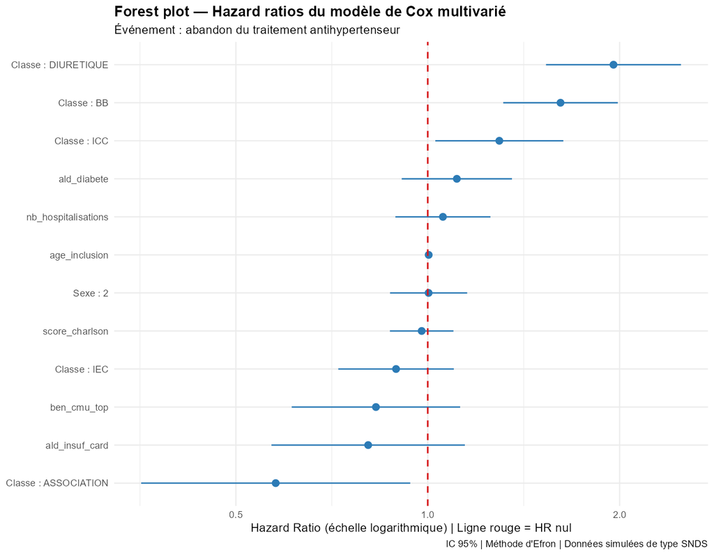

Forest plot — Hazard ratios ajustés du modèle de Cox multivarié

### 3.5.1 Vérification de l’hypothèse des risques proportionnels

Test de Schoenfeld — Vérification de l’hypothèse des risques proportionnels

| Covariable | chisq | df | p | Hypothèse PH |
| --- | --- | --- | --- | --- |
| classe_atc | 3.825 | 5 | 0.575 | ✅ Vérifiée \| |
| age_inclusion | 1.061 | 1 | 0.303 | ✅ Vérifiée \| |
| factor(ben_sex_cod) | 0.004 | 1 | 0.947 | ✅ Vérifiée \| |
| ald_diabete | 0.132 | 1 | 0.717 | ✅ Vérifiée \| |
| ald_insuf_card | 0.073 | 1 | 0.787 | ✅ Vérifiée \| |
| score_charlson | 0.332 | 1 | 0.565 | ✅ Vérifiée \| |
| nb_hospitalisations | 0.004 | 1 | 0.947 | ✅ Vérifiée \| |
| ben_cmu_top | 0.148 | 1 | 0.701 | ✅ Vérifiée \| |
| GLOBAL | 5.829 | 12 | 0.924 | ✅ Vérifiée \| |

L’hypothèse des risques proportionnels est vérifiée pour toutes les covariables (test global : p = 0.92).

# 4 Analyses de sensibilité

## 4.1 S1 — Définitions alternatives de l’abandon

S1 — HR selon différentes définitions de l’abandon

| Analyse | Covariable | HR (IC 95%) | p-valeur |
| --- | --- | --- | --- |
| Seuil strict (330j) | classe_atcASSOCIATION | 0.65 (0.50–0.84) | 0.001 |
| Seuil strict (330j) | classe_atcBB | 1.67 (1.48–1.89) | 0.000 |
| Seuil strict (330j) | classe_atcDIURETIQUE | 1.97 (1.69–2.28) | 0.000 |
| Seuil strict (330j) | classe_atcICC | 1.28 (1.12–1.47) | 0.000 |
| Seuil strict (330j) | classe_atcIEC | 0.96 (0.85–1.08) | 0.493 |
| Seuil large (300j) | classe_atcASSOCIATION | 0.67 (0.52–0.88) | 0.003 |
| Seuil large (300j) | classe_atcBB | 1.67 (1.47–1.90) | 0.000 |
| Seuil large (300j) | classe_atcDIURETIQUE | 1.97 (1.69–2.29) | 0.000 |
| Seuil large (300j) | classe_atcICC | 1.30 (1.13–1.50) | 0.000 |
| Seuil large (300j) | classe_atcIEC | 0.94 (0.83–1.06) | 0.336 |

Les résultats sont **stables** quelle que soit la définition retenue.

## 4.2 S2 — Patients sans comorbidité majeure

S2 — HR chez les patients sans comorbidité (Charlson = 0)

| Covariable | HR (IC 95%) | p-valeur |
| --- | --- | --- |
| classe_atcASSOCIATION | 0.77 (0.44–1.34) | 0.351 |
| classe_atcBB | 1.80 (1.39–2.35) | <0,001 |
| classe_atcDIURETIQUE | 1.79 (1.29–2.48) | <0,001 |
| classe_atcICC | 1.52 (1.14–2.03) | 0.004 |
| classe_atcIEC | 0.86 (0.65–1.13) | 0.282 |

Les résultats sont **cohérents** avec l’analyse principale.

## 4.3 S3 — Analyses par sous-groupes

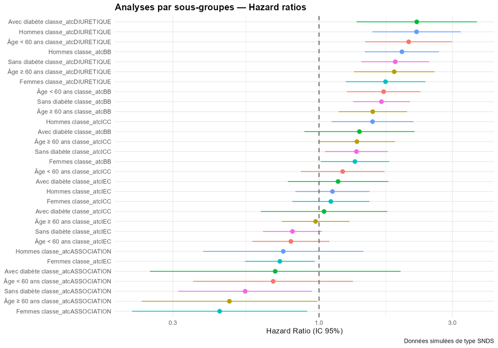

Forest plot — Analyses par sous-groupes

Aucune hétérogénéité majeure n’est observée entre les sous-groupes.

## 4.4 S4 — Modèle de risques compétitifs

S4 — HR cause-specific pour l’abandon (modèle risques compétitifs)

| Covariable | HR (IC 95%) | p-valeur |
| --- | --- | --- |
| classe_atcASSOCIATION | 0.58 (0.35–0.94) | 0.026 |
| classe_atcBB | 1.62 (1.32–2.00) | <0,001 |
| classe_atcDIURETIQUE | 1.97 (1.54–2.51) | <0,001 |
| classe_atcICC | 1.30 (1.03–1.64) | 0.026 |
| classe_atcIEC | 0.90 (0.73–1.10) | 0.3 |

> Seulement 1 décès sur 4500 patients. Le biais de risque compétitif est **négligeable** dans cette cohorte.

## 4.5 S5 — E-value

S5 — E-value : robustesse aux facteurs de confusion non mesurés

| Indicateur | Valeur |
| --- | --- |
| HR ponctuel IEC vs ARA2 | 0.911 |
| IC 95% bas | 0.732 |
| IC 95% haut | 1.134 |
| E-value (HR ponctuel) | 1.420 |
| E-value (borne IC bas) | 1.000 |

# 5 Discussion

## 5.2 Forces méthodologiques

- Utilisation du score de propension pour contrôler le biais d’indication
- Appariement 1:1 avec caliper standard (0,2 SD du logit PS)
- Vérification systématique de la balance des covariables (love plot, SMD)
- Validation de l’hypothèse des risques proportionnels (test de Schoenfeld)
- Cinq analyses de sensibilité pour évaluer la robustesse des résultats
- Quantification du biais résiduel par l’E-value

# 6 Conclusion

Cette analyse démontre la faisabilité d’une étude pharmaco- épidémiologique rigoureuse sur données de type SNDS, en mobilisant les méthodes standards de l’inférence causale sur données observationnelles. Les résultats sont cohérents avec la littérature et robustes aux analyses de sensibilité.

Sur le plan méthodologique, ce travail illustre l’apport du score de propension pour construire des comparaisons valides en l’absence de randomisation — approche au cœur des études publiées par le GIS EPI-PHARE sur le SNDS.

# 7 Références

- Austin PC (2011). An Introduction to Propensity Score Methods for Reducing the Effects of Confounding in Observational Studies. *Multivariate Behavioral Research*, 46(3), 399–424.
- Cox DR (1972). Regression Models and Life-Tables. *Journal of the Royal Statistical Society B*, 34(2), 187–220.
- Fine JP, Gray RJ (1999). A Proportional Hazards Model for the Subdistribution of a Competing Risk. *Journal of the American Statistical Association*, 94(446), 496–509.
- Hernán MA, Robins JM (2016). Using Big Data to Emulate a Target Trial When a Randomized Trial Is Not Available. *American Journal of Epidemiology*, 183(8), 758–764.
- Kaplan EL, Meier P (1958). Nonparametric Estimation from Incomplete Observations. *Journal of the American Statistical Association*, 53(282), 457–481.
- VanderWeele TJ, Ding P (2017). Sensitivity Analysis in Observational Research: Introducing the E-Value. *Annals of Internal Medicine*, 167(4), 268–274.

# 8 Informations de session

| Élément | Valeur |
| --- | --- |
| Version R | 4.4.0 |
| Système | Windows 11 x64 (build 26200) |
| Date d’analyse | 10/06/2026 |

Versions des packages principaux

| Package | Version |
| --- | --- |
| survival | 3.8.6 |
| survminer | 0.5.2 |
| MatchIt | 4.7.2 |
| tableone | 0.13.2 |
| dplyr | 1.1.4 |
| ggplot2 | 4.0.3 |